# Test a Perceptual Phenomenon

```python
## Importing pandas library and numpy for processing the data to pull out the results
## and Matplotlib library for plotting grpahs

import pandas as pd
import numpy as np
import matplotlib.pyplot as plt
from math import *
import pprint
```

```python
## Loading the data in pandas data frame

stroop_data = pd.read_csv('./stroopdata.csv')

## Displaying the table

stroop_data.head(5)
```

|  | Congruent | Incongruent |
| --- | --- | --- |
| 0 | 12.079 | 19.278 |
| 1 | 16.791 | 18.741 |
| 2 | 9.564 | 21.214 |
| 3 | 8.630 | 15.687 |
| 4 | 14.669 | 22.803 |

```python
## Numbering the Subject whose data is provided to us under the S_no Column
stroop_data['S_no'] = stroop_data.index + 1
stroop_data.head(5)
```

|  | Congruent | Incongruent | S_no |
| --- | --- | --- | --- |
| 0 | 12.079 | 19.278 | 1 |
| 1 | 16.791 | 18.741 | 2 |
| 2 | 9.564 | 21.214 | 3 |
| 3 | 8.630 | 15.687 | 4 |
| 4 | 14.669 | 22.803 | 5 |

## Q1 What is our independent variable? What is our dependent variable?

## Ans :-

- **1. Here the Word Condition (Congruent or Incongruent) is the independent parameters**
- **2. While the Time taken to name the ink colour is the dependent variable**

## Q2 What is an appropriate set of hypotheses for this task? What kind of statistical test do you expect to perform? Justify your choices.

## Ans :-

- Here we will consider the Null Hypothesis and a Alternative Hypothesis
- Null Hypothesis:- In this Hypothesis we generally make a statement without any proof or data and we don’t consider any relationship between the two variables it lacks observation
1. Null Hypothesis is indirect and implicit and is denoted by H0(H-zero) and they carry‘=‘sign in their formulation
1. Mathematical form H0 : μ = k, H0 : μ < = k, H0 : μ > = k
1. Alternative Hypothesis is based on the statistical results and observation where we establish some relationship between the two variables based on the observation
1. Alternative hypotheses is Direct and explicit and is denoted by H1(H-one) or Ha and they carry '≠' sign in mathematical formulation
2. Mathematical form H1 : μ ≠ k, H1 : μ > k, H1 : μ < k
3. Here μ represents the parameters we are working with like proportion etc
4. 'k’ or μI represents a content value or the intervention of the test

### For the given scenario we have

- Hypothesis
- Null :- μc = μI
- [Time required to recognise the congruent and incongruent word remians same]
- Alternative :- μc ≠ μI
- [Time required to recognise the congruent and incongruent word is not same]
- Where μI = mean of the response time for Incongruent words
- Where μc = mean of the response time for congruent words
- Here in the hypothesis we area dealing with population means of both congruent and incongruent words since we are generalising the hypothesis for the population
- here with the help of sample of the given population we are trying to formulate a result using which we can either support our hypothesis or Reject it but the result is for the entire populations.

### Here we will choose The Dependent Samples t-Test since both the congruent and incongruent words recognition have something in common i.e by performing one test the experience you gain(practice) can impact the other one slightly

- Since we know the mean and stanard deviation of the sample and not of the popultion **T-test is the way to go** since we require to have the sample size and mean for the entire populatin to perform Z-Test

### Here we assume that given data set is a sample of a larger population hence we will perform dependent T test .

## Q3 Report some descriptive statistics regarding this dataset. Include at least one measure of central tendency and at least one measure of variability.

## Ans:-

- The Mean for both the groups ( Centeral Tendency) and Standard deviation for both the groups ( Variability) are mentioned below

mean = (Sum of the set)/(no of the elements in the set)

```python
## Cconverting data frame to arrays

congruent = stroop_data['Congruent']

incongruent= stroop_data['Incongruent']

subject_sno = stroop_data['S_no']

## Checking the array

print(congruent)

print(incongruent)

print(subject_sno)
```

```
0     12.079
1     16.791
2      9.564
3      8.630
4     14.669
5     12.238
6     14.692
7      8.987
8      9.401
9     14.480
10    22.328
11    15.298
12    15.073
13    16.929
14    18.200
```

[output cut: 60 more lines]

```python
## Mean and STD for Congruent Words and In Congruent Word
print("Congruent words \nMean = {} \t STD = {}".format(round(congruent.mean(),2) , round(congruent.std(),2)))
print("Congruent words \nMean = {} \t STD = {}".format(round(incongruent.mean(),2), round(incongruent.std(),2)))
```

```
Congruent words
Mean = 14.05 	 STD = 3.56
Congruent words
Mean = 22.02 	 STD = 4.8
```

## Q4 Provide one or two visualisations that show the distribution of the sample data. Write one or two sentences noting what you observe about the plot or plots.

## ANS:-

- Plots are drawn below

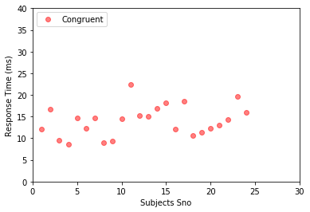

```python
## Plotting the scatter plot for Congruent variables
# Fixing random state for reproducibility

plt.plot(subject_sno, congruent, 'ro',alpha = 0.5,marker=r'o',label="Congruent")
plt.axis([0, 30, 0, 40])
plt.xlabel("Subjects Sno")
plt.ylabel("Response Time (ms)")
plt.legend(loc=2)
plt.show()
```

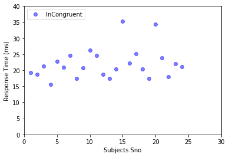

```python
## Plotting the scatter plot for InCongruent variables
# Fixing random state for reproducibility
plt.plot(subject_sno, incongruent, 'ro',c='b',alpha = 0.5,marker=r'o',label="InCongruent")
plt.axis([0, 30, 0, 40])
plt.xlabel("Subjects Sno")
plt.ylabel("Response Time (ms)")
plt.legend(loc=2)
plt.show()
```

### Observation :-

- Again in the scatter plot we can see the range for max points in **congruent words is 8-20s**
- While that of the **In-Congruent words is 15-30s**
- Hence we can derive a infrence that Congruent words take less response time as compared to the Incongruent words

## Q5 Now, perform the statistical test and report your results. What is your confidence level and your critical statistic value? Do you reject the null hypothesis or fail to reject it? Come to a conclusion in terms of the experiment task. Did the results match up with your expectations?

### Hypothesis

- **Null** :- μ = μI
- [Time required to recognise the congruent and incongruent word remians same]
- **Alternative** :- μ ≠ μI
- [Time required to recognise the congruent and incongruent word is not same]

```python
n = len(stroop_data)
df = n-1

print( "Dample size (n) =       {} \nDegree of freedom (df)= {}".format(n,df) )
```

```
Dample size (n) =       24
Degree of freedom (df)= 23
```

- Here we will perfomr **two tail** dependent variable t test
- confidence value = 95%
- $\alpha$ = 0.05
- t(critical) = $\pm$2.069 using t-table
- sample size n = 24
- df(degree of freedom) = n-1 = 23

```python
## Calcutating the point estimate
## P = μi-μc (mean of incongruent - mean of congruen)

point_estimate = incongruent.mean() - congruent.mean()

print("Point estimate P = {}".format(round(point_estimate,2)))
```

```
Point estimate P = 7.96
```

```python
## Calculating the Sample Standard devation of the difference s
## s = sqrt(SDD/(n-1)

## Calcuating the difference of the values for both the sample

stroop_data['Difference'] = stroop_data['Incongruent'] - stroop_data['Congruent']

## Subtracting mean from the differecne

stroop_data['Difference - mean'] = stroop_data['Difference'] - stroop_data['Difference'].mean()

## Squaring the difference to give us

stroop_data['Squared-Difference'] = stroop_data['Difference - mean'] * stroop_data['Difference - mean']

## Calculating the SDD Sum of squared difference

SDD = stroop_data['Squared-Difference'].sum()

## Calculating the variance v = SDD/(n-1)
## [** we are using bessels correction as the given data is a sample and not a population]

varience = SDD/(n-1)

## Calcualting s = stadnard devation for the sample difference

s = sqrt(varience)

stroop_data
```

|  | Congruent | Incongruent | S_no | Difference | Difference - mean | Squared-Difference |
| --- | --- | --- | --- | --- | --- | --- |
| 0 | 12.079 | 19.278 | 1 | 7.199 | -0.765792 | 0.586437 |
| 1 | 16.791 | 18.741 | 2 | 1.950 | -6.014792 | 36.177719 |
| 2 | 9.564 | 21.214 | 3 | 11.650 | 3.685208 | 13.580760 |
| 3 | 8.630 | 15.687 | 4 | 7.057 | -0.907792 | 0.824086 |
| 4 | 14.669 | 22.803 | 5 | 8.134 | 0.169208 | 0.028631 |
| 5 | 12.238 | 20.878 | 6 | 8.640 | 0.675208 | 0.455906 |
| 6 | 14.692 | 24.572 | 7 | 9.880 | 1.915208 | 3.668023 |
| 7 | 8.987 | 17.394 | 8 | 8.407 | 0.442208 | 0.195548 |
| 8 | 9.401 | 20.762 | 9 | 11.361 | 3.396208 | 11.534231 |
| 9 | 14.480 | 26.282 | 10 | 11.802 | 3.837208 | 14.724168 |
| 10 | 22.328 | 24.524 | 11 | 2.196 | -5.768792 | 33.278957 |
| 11 | 15.298 | 18.644 | 12 | 3.346 | -4.618792 | 21.333236 |
| 12 | 15.073 | 17.510 | 13 | 2.437 | -5.527792 | 30.556481 |
| 13 | 16.929 | 20.330 | 14 | 3.401 | -4.563792 | 20.828194 |
| 14 | 18.200 | 35.255 | 15 | 17.055 | 9.090208 | 82.631888 |
| 15 | 12.130 | 22.158 | 16 | 10.028 | 2.063208 | 4.256829 |
| 16 | 18.495 | 25.139 | 17 | 6.644 | -1.320792 | 1.744491 |
| 17 | 10.639 | 20.429 | 18 | 9.790 | 1.825208 | 3.331385 |
| 18 | 11.344 | 17.425 | 19 | 6.081 | -1.883792 | 3.548671 |
| 19 | 12.369 | 34.288 | 20 | 21.919 | 13.954208 | 194.719930 |
| 20 | 12.944 | 23.894 | 21 | 10.950 | 2.985208 | 8.911469 |
| 21 | 14.233 | 17.960 | 22 | 3.727 | -4.237792 | 17.958878 |
| 22 | 19.710 | 22.058 | 23 | 2.348 | -5.616792 | 31.548349 |
| 23 | 16.004 | 21.157 | 24 | 5.153 | -2.811792 | 7.906172 |

```python
print("Squared difference SDD = {}\nVarience v = {}\nSample Standard devation of the difference s = {}"
      .format(round(SDD,2),round(varience,2),round(s,2)))

## Calculating Standard error SE
## SE = s/sqrt(n)

SE = s/sqrt(n)
print("Standard error SE = {}".format(round(SE,2)))
```

```
Squared difference SDD = 544.33
Varience v = 23.67
Sample Standard devation of the difference s = 4.86
Standard error SE = 0.99
```

```python
## Computing t statistic
## t = Pointestimate/SE
tc = 2.069
t = point_estimate/SE

print("t statistic = {}".format(round(t,4)))

print("Since t {} > tcritical {} \nwe can recjet the null hypothesis".format(round(t,4),tc))
```

```
t statistic = 8.0207
Since t 8.0207 > tcritical 2.069
we can recjet the null hypothesis
```

### Conclusion

- Hence we Conclude that it takes less time to recognise Congruent words(Words named and coloured the same) while it takes a bit more time to recognise In-Congruent Words.
- Since t is greater than t critical it lies in the region where its unlikely to occur by chance and hence we cannot have same response time for congruent and incogeuent words
- **Hence we Reject the null hypothesis that their is no difference in response time for the two types of the word**

## Q6 Optional: What do you think is responsible for the effects observed? Can you think of an alternative or similar task that would result in a similar effect? Some research about the problem will be helpful for thinking about these two questions!

## ANS:-

- 1 .The ability of our brain to create a image for remembering different objects is the cause since on looking at a colour our brain can response very quickly due to perceptive memory while for processing the same color name on different color takes time
- 1. Yes jumbled up images and words ie if we display a image of a ship and call it a tree or vice versa it should show similar kind of impact as here also our brain relies on perceptive memory
- 1. It can also be done by interchanging the names of two people for a day and then see the difference your selves !

## Resources

- 1. Keydifference :- link
- 1. Wikipedia:- link
- 1. matplotlib:- link